# Analyse de sensibilité d’un modèle de socio-écosystème marin

Constance Bau

Ifremer (Institut Français De Recherche pour l’Exploitation de la Mer) - Avenue Jean Monnet 34203 Sète

# 1 Résumé

L’analyse de sensibilité est une méthode qui permet de quantifier l’influence des paramètres d’entrée sur les variables de sorties. Elle est très utilisée dans l’étude des modèles complexes car elle permet de cibler les incertitudes importantes à prendre en compte dans une évaluation de la robustesse des sorties du modèle. Elle permet aussi de classer les paramètres par ordre d’influence sur les sorties du modèle et ainsi faire du factor fixing, c’est-à-dire fixer les paramètres peu influents à leur valeur de référence.

La plupart des méthodes d’analyse de sensibilité utilisées repose sur une hypothèse d’indépendance entre les paramètres d’entrée, ce qui, on le sait, est rarement le cas dans les modèles. Nous avons donc étudié différentes méthodes d’analyse de sensibilité prenant en compte la dépendance entre les paramètres d’entrée (Shapley et Shapley HSIC (Da Veiga et al. (2021))) et nous avons choisi d’utiliser la méthode Sobol-MDA (Bénard, Da Veiga, and Scornet (2022)). Cette méthode repose sur la construction d’un modèle statistique de forêt aléatoire et les indices de sensibilité sont calculés à partir de l’estimation de l’importance de chaque covariables (paramètres du modèle complexe).

Dans cette étude, nous avons étudié la sensibilité d’une pêcherie langoustinière modélisée avec ISIS-Fish. ISIS-Fish est un modèle de dynamique de pêcherie utilisé pour construire et évaluer des scénarios de gestion spatialisée des pêches. Après avoir fait une hypothèse de dépendance sur 5 paramètres incertains d’ISIS-Fish, nous avons construit un plan d’expérience et réalisé les simulations de ce plan avec ISIS-Fish. Nous avons ensuite ajusté un modèle de forêt aléatoires à chaque variable de sortie du modèle (biomasse, biomasse de géniteurs et captures) et estimé les indices de Sobol totaux avec l’algorithme Sobol-MDA.

Tout d’abord, en se basant sur le R² (le coefficient de corrélation partielle qui correspond au pouvoir descriptif ou explicatif), on note que les 3 modèle de forêt aléatoires s’ajustent bien. On remarque ensuite que le classement des paramètres par ordre d’influence change en fonction de la sortie étudiée. De plus, il évolue en fonction des années, par exemple, pour la biomasse, la fécondité est 4ème sur 5 la 1ère année (peu d’influence) mais elle est 2ème sur 5 la 4ème année (nettement plus influente). Ce qui peut s’expliquer par le fait que la première année de simulation est caractérisée par une très forte abondance de jeunes langoustines de l’année (recrutement) dont le poids augmente avec le temps.

Pour évaluer l’erreur que l’on aurait pu faire en ne prenant pas en compte la dépendance entre les paramètres, nous avons aussi calculé les indices de sensibilité en supprimant la dépendance des paramètres d’entrée. Nous avons remarqué des différences dans les valeurs des indices. Néanmoins, dans la plupart des cas, cette différence n’est pas assez grande pour changer le classement par ordre d’influence des paramètres. On en déduit donc que l’on aurait eu des résultats assez similaires sans prendre en compte la dépendance.

Finalement, nous avons voulu comprendre comment l’intensité de la dépendance influait sur l’analyse de sensibilité. Nous avons montré qu’une augmentation de la corrélation entre les paramètres peut changer le classement par ordre d’influence des paramètres. La valeur des indices de Sobol MDAdes paramètres corrélés diminue significativement lorsque la corrélation augmente. Comme le Sobol-MDA mesure l’augmentation de l’erreur du random forest lorsque l’un des paramètres est retiré du processus de prédiction, il est normal que l’indice de Sobol total d’un paramètre fortement corrélé à un autre diminue puisque l’information qu’il apportait est contenue dans un autre paramètre. Dans une configuration à forte corrélation, il faut néanmoins rester prudent si l’on souhaite faire du factor fixing. En effet, dans une analyse de sensibilité mêlant des paramètres indépendants et d’autres très corrélés, les indices de sensibilité des paramètres corrélés pourraient être classés peu influents relativement aux paramètres indépendants. On pourrait alors être tenté de fixer les paramètres dependants à leur valeur de référence et fausser l’analyse de la robustesse des variables de sortie du modèle.

# 2 Introduction

De nos jours, la diversification des usages en mer ne cesse de s’amplifier (éolien en mer, extraction de granulats, conchyliculture, etc.) et l’espace maritime fait plus que jamais l’objet de conflits sociaux, économiques et environnementaux. Dans ce contexte, la gestion spatialisée des activités humaines proposée par la Commission Européenne (directive établissant un cadre pour la planification spatiale de l’espace maritime (milieumarinfrance (2014)), directive cadre stratégie pour le milieu marin (milieumarinfrance (2008)), politique commune des pêches) prend tout son sens. Les outils de modélisation spacialisés deviennent dès lors une approche incontournable pour aider à la prise de décision en apportant de la connaissance sur les conséquences possibles de réglementations spatiales complémentaires des mesures actuelles (Mahévas and Pelletier (2004)). Pour appréhender une gestion écosystémique spatialisée des pêches, nous utilisons le modèle de simulation ISIS-Fish (isis-fish.org). Ce modèle spatialisé permet de décrire la dynamique spatio-temporelle des flottilles de pêche et son incidence sur les principales espèces capturées. Pour permettre le choix d’une règlementation parmi plusieurs il est indispensable d’évaluer la robustesse des sorties du modèle (Saltelli et al. (2004)).

Toutes les incertitudes en entrée du modèle n’influent pas dans les mêmes ordres de grandeur sur les sorties du modèle. L’analyse de sensibilité est une méthode qui permet de quantifier l’influence des paramètres d’entrée sur les variables de sorties (Faivre et al. (2013)). En plus de permettre de cibler les incertitudes importantes à prendre en compte dans une évaluation de la robustesse des sorties du modèle, l’analyse de sensibilité permet de trouver les covariables les plus influentes dans le but de : (i) trouver un petit nombre de covariables maximisant la précision ou (ii) classer les covariables par ordre d’influence pour l’interprédation du mécanisme de prédiction du modèle (Genuer, Poggi, and Tuleau-Malot (2010)). Les stratégies adoptées varient selon l’objectif suivi. Par exemple, si deux variables influentes sont fortement corrélées, l’une sera écartée dans le cas (i) tandis que les deux seront gardées dans le cas (ii). Des méthodes d’analyse de sensibilité supposant l’indépendance entre les entrées ont d’abord été développées (Faivre et al. (2013), Saltelli et al. (2004)). Puis, comme dans de nombreuses applications il est courant que les variables d’entrée aient une structure de dépendance statistique (connue ou supposée), la recherche s’est alors portée sur des méthodes plus complexes prenant en compte la dépendance entre les entrées (Da Veiga et al. (2021)).

Les indices de Sobol (Da Veiga et al. (2021)) font partie des méthodes d’analyse de sensibilité qui ne prennent pas en compte la dépendance entre les paramètres d’entrée. Cette méthode permet, grâce une décomposition exacte de la variance, de calculer des indices de sensibilité dans le cadre d’entrées indépendantes (voir annexe). Les effets de Shapley (Da Veiga et al. (2021)), initialement formulés pour mesurer la contribution au jeu de chaque joueur, dans le cadre de la théorie des jeux coopératifs, prennent en compte la dépendance entre les paramètres d’entrée dans le calcul des indices. Ils résultent, dans le cas de l’analyse de sensibilité, d’une allocation directe d’une part de la variance de la sortie à chaque entrée (voir annexe). Cette méthode est très intéressante dans le sens où elle prend en compte la corrélation entre les entrées et qu’elle repose sur une formule exacte faisant intervenir les indices de Sobol. Néanmoins, l’estimation des indices de Shapley peut s’avérer compliquée en grande dimension car elle nécessite de considérer toutes les permutations possibles des variables d’entrée. Par ailleurs, pour remédier au fait que dans certains cas la variance ne représente pas très fidèlement la variabilité de la distribution de la sortie, des mesures d’importance du moment indépendant ont été introduites. Ces mesures visent à comparer la loi de probabilité de la sortie (notée Y) avec celles des différentes entrées (notées X) pour voir à quel point celles-ci se ressemblent. Parmi ces mesures, on peut citer l’indice de Shapley-HSIC (Da Veiga (2021)), formulé en utilisant les indices Hsic qui calculent la dépendance entre deux variables Y et X comme la distance entre leur distribution jointe et le produit de leurs distributions marginales (voir annexe). Nous nous sommes finalement intéressées à une dernière méthode utilisant un algorithme d’apprentissage automatique qui repose sur la construction d’une forêt aléatoire (random forest en anglais), pour construire un méta-modèle et ensuite estimer les indices de sensibilité de ce méta-modèle.

Les random forests sont des algorithmes d’apprentissage statistique capables de résoudre des problèmes de régression et de classification (Breiman (2001)). Ils peuvent s’appliquer à des données de grande dimension et aux sorties multivariées. Pour permettre l’interprétation des random forests, l’analyse d’importance des variables est principalement utilisée. Les covariables en entrée (X) sont alors classées par ordre décroissant de leur importance dans le processus de prédiction de l’algorithme. L’algortihme Sobol-MDA (Bénard, Da Veiga, and Scornet (2022)), basé sur ranger, une implémentation rapide de random forest (Wright and Ziegler (2015)), permet la mesure d’importance des covariables dans le cadre dépendant. De plus il a été prouvé que cet algorithme converge vers l’indice de Sobol total et des experimentations sur des fonctions théoriques ont montré que le classement des variables par ordre d’importance obtenu avec cet algortihme est le même que celui obtenu avec les calcul théorique des indices de Sobol totaux (voir Bénard, Da Veiga, and Scornet (2022)).

Construire un métamodèle permet de prédire les sorties Y du modèle pour tout entrée X du domaine de définition beaucoup plus simplement et rapidement (Faivre et al. (2013)). On peut ainsi obtenir des prédictions sur un échantillon d’entrée de grande taille, et utiliser ces données pour évaluer et analyser la relation entre les différentes covariables d’entrée (X) et les sorties (Y) du métamodèle. Il faut néanmoins rester prudent car les indices obtenus sont les indices de sensibilité du métamodèle et non du modèle initial. Néanmoins, plus $R^2$, le coefficient de corrélation partielle qui correspond au pouvoir descriptif ou explicatif d’un métamodèle, est proche de 1, plus la valeur des indices du métamodèle est proche de la valeur des indices du modèle initial.

Dans le cadre de cette étude, nous avons tout d’abord exploré les sorties du modèle pour comprendre leur dynamique. Puis, à partir des données des simulations de notre modèle, nous avons construit des métamodèles random forests d’une pêcherie langoustinière paramétrée avec ISIS-Fish (voir MIMI (2022) et MIMI (2023)). Ces métamodèles prennent en entrée 5 paramètres. Après avoir vérifié que ces métamodèles ajustaient bien notre modèle, nous les avons utilisé pour l’analyse de sensibilité. Dans un premier temps, nous avons observer, année par année, le classement par influence des paramètres d’entrée du modèle puis nous avons regardé la dynamique temporelle des indices de sensibilité. Cela nous a permis d’évaluer les paramètres les plus influents, ce qui est très utlile si l’on souhaite faire du factor fixing par exemple, c’est-à-dire choisir les entrées à fixer. Dans un deuxième temps, en ayant en tête un objectif plus théorique cette fois, nous avons comparer les valeurs des indices dans le cas de paramètres dépendants et indépendants ainsi que les valeurs des indices obtenues selon les différentes méthodes de calcul. De plus, nous avons cherché à voir de quelle manière la corrélation entre les paramètres d’entrée fait varier la valeur des indices de sensibilité.

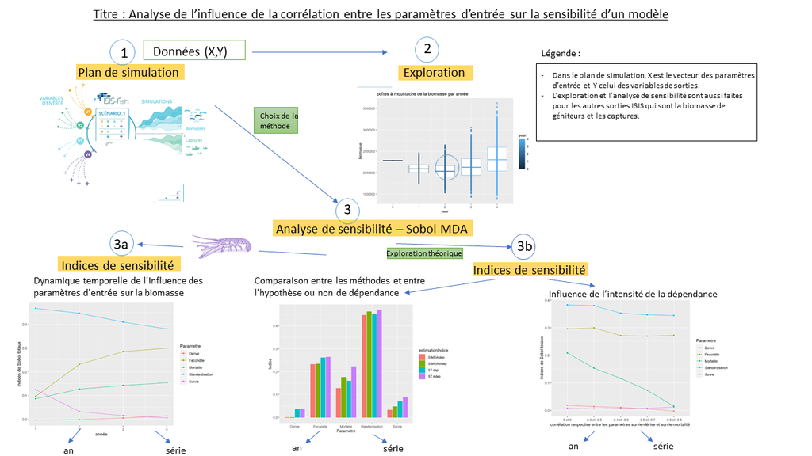

Graphical abstract

# 3 Méthode

Dans cette partie nous présentons les randoms forests, la mesure d’importance Sobol-MDA ainsi que la démarche mise en oeuvre.

## 3.1 Méthodes utilisées

Les random forests sont des algorithmes qui, après avoir été entraînés sur des données d’entraînement, sont capables de prédire une valeur de sortie y pour n’importe quelle valeur d’entrée. Les random forests sont constitués d’arbres de régression si Y est continue ou de classification si Y est catégorielle, ils sont présentés dans Breiman (2017). Dans notre cas, le random forest sera composé d’arbres de régression car la sortie Y de notre modèle est continue. Nous nous baserons sur le livre de Breiman (2017) pour expliquer en détails la construction de ces arbres puis nous nous baserons sur les articles de Breiman (2001) et de Scornet (2023) pour comprendre la construction d’une forêt aléatoire et l’estimation de son erreur généralisée. Ensuite nous présenterons ranger (détaillé dans Wright and Ziegler (2015)), une implémentation rapide et adaptée aux grandes dimensions de random forest utlisée dans Sobol-MDA (Bénard, Da Veiga, and Scornet (2022)) pour la construction du random forest. Finalement, nous détaillerons la manière dont Sobol-MDA calcule les mesures d’importance de chaque covariables ainsi que les hypothèses et résultats de convergence de cet algorithme.

### 3.1.1 Arbres de régression

Les CART (Classification And Regression Tree décrit dans Breiman (2017) ) sont les composants élémentaires d’une forêt aléatoire. Nous allons voir dans la suite comment se déroule leur construction. L’algorithme de construction effectue un partitionnement récursif des données, puis estime un modèle très simple dans chaque élément de la partition. Un élément de la partition est appelé feuille de l’arbre. En résumé, le but est de choisir “intelligemment” une caractéristique puis de couper astucieusement les données selon cette caractéristique de sorte que la prévision $y_i$ soit la moyenne des observations dans la feuille. On recommence ensuite ce processus sur les sous-arbres obtenus jusqu’à notre critère d’arrêt. Voyons cela en détails.

On considère qu’on a n individus et on note $X_i$ le vecteur des p covariables d’entrée, on a alors $X_{i,k}$ avec $i \in \{1,...,n\}$ et $k \in \{1,...,p\}$. On note $Y_i$ la variable de sortie à prédire associée au vecteur d’entrée $X_i$. L’objectif est de découper l’espace en J régions $R_1,..., R_j$ (les feuilles de l’arbre) qui minimisent :
$$RSS=\sum_{j=1}^{J}{\sum_{i\in
R_j}{}}{(y_{i}-\hat{y_j})^2}$$

où $\hat{y_j}$ est la moyenne des sorties obtenues avec les entrées situées dans la région $R_j$ c’est à dire $\hat{y_j}=\frac{1}{n_j}\sum_{i\in R_j}y_i$ avec $n_j$ le nombre d’observations dans la feuilles $R_j$. Dans le CART de base on suppose que $\hat{y_j}=a$ où a est une constante mais il existe des variantes de type $\hat{y_j}=x \beta$.

Pour faire cela, à chaque noeud il faut choisir une variable (i.e une composante du vecteur X ) selon laquelle on divise les données. On considère les zones $R_{-}(k,s)=\{x_i \text{ tel que }x_{i,k}<s\}$ et $R_{+}(k,s)=\{x_i\text{ tel que }x_{i,k}\geq s\}$. A chaque étape, CART choisit la variable j et le seuil s (on a (k,s) $\in C$ l’ensemble des coupes possibles dans les données d’un noeud) minimisant la variance intra-groupe définie comme suit :
$$VI=\frac{1}{n_{noeud}}\sum_{i \text{ tel que }
X_i \in R_{-}(j,s)}(y_i-\hat{y}_{R_{-}})^2+\frac{1}{n_{noeud}}\sum_{i
\text{ tel que } X_i\in R_{+}(j,s)}(y_i-\hat{y}_{R_{+}})^2$$
où $n_{noeud}$ est le nombre de données dans le noeud que l’on cherche à diviser (pour le noeud initial de l’arbre on a donc $n_{noeud}=n$). Minimiser la somme des carrée des résidus revient donc à minimiser
$$RSS=\sum_{j=1}^{J}n_jVj$$
où $V_j=\frac{1}{n_j}\sum_{i\in R_j}(y_i-\hat{y_j})^2$ est la variance intra-groupe et $n_j$ le nombre d’observations dans chaque feuille de l’arbre.

Dans l’algorithme random forest que nous utilisons, à chaque noeud de l’arbre, on recherche quelle est la meilleure division non sur toutes les covariables possibles mais sur un échantillon de m covariables tirées aléatoirement et sans remplacement. La meilleure division est sélectionnée uniquement parmi ce m covariables (ce qui présente un gain de temps considérable pour les problèmes de grandes dimensions). Par défaut, on prend $m=\frac{p}{3}$ en régression mais on peut aussi prendre $m=\sqrt{p}$ dans les cas de très grandes dimensions.

Concernant l’arrêt de l’algorithme de construction, deux critères sont principalement utilisés :

- un nombre d’observations q suffisamment petit dans les feuilles
- un critère d’erreur (ici la variance inter-groupe) inférieur à un seuil $\delta$

On peut choisir d’arrêter la récursion lorsque les deux critères sont vérifiés ou seulement lorsque l’un des deux est vérifié.

### 3.1.2 Construction d’une forêt aléatoire

Une forêt aléatoire n’est rien d’autre qu’un ensemble d’arbres de décision (dans notre cas d’arbres de régression). Ainsi, avant la construction de chaque arbre k on tire un échantillon aléatoire bootstrap $D_k$ de taille n dans l’échantillon intial D de taille n lui aussi, c’est-à-dire que l’on tire aléatoirement, uniformément et avec remise n vecteurs $x_i$ dans D. Cet échantillon $D_k$ servira alors de données d’entraînement pour l’arbre k. Les vecteurs $x_i$ qui n’ont pas été tirés (il y en a sûrement grâce au tirage avec remise) sont gardés de côté et constituent l’échantillon Out Of Bag de cet arbre. La prédiction par la forêt aléatoire est alors la moyenne des prédictions de chaque arbre de la forêt.

### 3.1.3 Calcul de l’erreur généralisée d’une forêt

Lorsque l’on construit une forêt aléatoire il est essentiel de savoir à quel point les prédictions qu’elle réalise sont précises. Pour cela il est possible d’estimer son erreur généralisée, ce qui revient en pratique à calculer le carré de la différence entre les valeurs de sortie des échatillons OOB et les valeurs de sortie des échantillons OOB prédites par la forêt et de moyenner le tout. Pour faire cela, l’algorithme suivant (présenté dans Cutler, Cutler, and Stevens (2012) et ) peut être utlisé :

Soit $D_k$ le k-ème échantillon bootstrap et $\hat{h}_j(x)$ la prédiction de $x$ à partir du j-ème arbre, pour $j = 1, . . . , J$. Pour $i = 1$ à $n$ :

1. Soit $J_i = \{ j : (x_i, y_i) \notin D_j\}$ et $|J_i|$ le cardinal de $J_i$.
2. Définissons la prédiction hors sac à $x_i$ comme suit :
   - $\hat{f}_{oob}(x_i) = \frac{1}{|J_i|} \sum_{j \in J_i} \hat{h}_j(x_i)$ pour la régression

L’erreur de généralisation est généralement estimée en utilisant l’erreur quadratique moyenne (MSE) hors sac suivante :

$$\text{MSE}_{oob} = \frac{1}{n} \sum_{i=1}^{n} (y_i -
\hat{f}_{oob}(x_i))^2$$

En résumé, pour chaque vecteur $x_i$ de l’ensemble d’entraînement initial D, on calcule sa prédiction par chacun des arbres k dont il n’a pas fait partie de l’ensemble d’entraînement $D_k$ et on moyenne ces prédictions pour avoir sa prédiction “par la forêt” (même si dans ce cas on ne l’a pas fait passer par tous les arbres). Ensuite, pour obtenir l’estimation généralisée de la forêt on fait la moyenne des différences au carré de la prévision de chaque $x_i$ et de sa valeur de sortie présente dans l’échantillon d’entraînement D.

### 3.1.4 Mesure d’importance des variables grâce à l’algorithme Sobol-MDA

Un des problèmes majeurs des random forests réside dans le fait que leurs propriétés mathématiques restent toujours un peu “magiques”, ce qui rend leur interprétabilité plus compliquée. Les personnes désireuses de se pencher d’avantage sur les forces à l’oeuvre derrière le processus de prédiction se sont alors principalement tournées vers l’importance des variables, une mesure de l’influence de chaque variable d’entrée dans la prédiction de la sortie. Dans l’article initial de Breiman (2001) sur les random forests, deux mesures d’importance sont présentées : la diminution moyenne de l’impureté (MDI, ou Gini importance, voir Breiman (2002) ) qui somme les diminutions pondérées de l’impureté sur tous les noeuds qui se divisent selon une covariable donnée, et la diminution moyenne de la précision (MDA, voir Breiman (2001)) qui permuttent les valeurs d’entrée d’une certaine variable dans les données du test et calcule la différence entre l’erreur sur l’ensemble test permutté et l’ensemble test original. L’un des grands avantages du MDI et du MDA réside dans leur capacité à prendre en compte l’intéraction entre les covariables mais d’un autre côté ils sont incapables de déterminer la partie de l’effet marginal d’une covariable donnée ((voir Wright, Ziegler, and König (2016)). Par ailleurs, MDA et MDI présentent tous les deux des biais non négligeables dans le cas de variables corrélés. Une version modifiée du MDA, nommée Sobol-MDA et expliquée dans Bénard, Da Veiga, and Scornet (2022), a ainsi été développée pour être capable de donner des résultats pertinents même dans des cas de corrélations entre les variables. Nous avons donc choisi d’utiliser Sobol-MDA pour évaluer la sensibilité de notre modèle.

Après avoir brièvement expliqué le fonctionnement du MDA, nous nous intéressons plus en détails à l’algorithme Sobol-MDA et nous verrons certains résultats de convergence de celui-ci.

#### 3.1.4.1 Présentation et limites du MDA

Le MDA, mesure de la diminution de la précision en français, a été initialement introduit pas Breiman dans son article Breiman (2001). Il repose sur le fonctionnement suivant : les valeurs d’une covariable spécifique sont permutées pour casser sa relation avec la variable de sortie. La précision prédictive est alors calculée pour cet ensemble de donées permutées. La différence entre la précision de l’ensemble dégradé et la précision de l’ensemble intial est alors calculée, cette différence donne la mesure d’importance de la covariable pour laquelle on a permuté les valeurs. Une grande diminution de la précision signifie que la variable considérée a une grande influence dans le mécanisme de prédiction. Bien que cette mesure soit très utilisée en pratique, on ne sait que très peu de choses sur ces propriétés statistiques. Sa convergence vers les indices de Sobol totaux n’a pas pu être prouvée et de nombreuses études empiriques ont montré que, lorsque les covariables sont dépendantes, le MDA ne détecte pas certaines variables influentes. Pour tenter d’y remédier, Williamson et al. (2023) proposent de mesurer la diminution de la précision entre la forêt originale et une forêt entraînée sans l’une des covariables. Néanmoins, comme il faut réentraîner la forêt et calculer sa précision autant de fois qu’il y a de covariables, cette méthode a un coût de calcul très élevé et n’est pas adaptée aux grandes dimensions.

#### 3.1.4.2 Sobol-MDA

La mesure d’importance Sobol-MDA propose de mimer l’entraînement d’une forêt sans l’une des covariables sans avoir besoin de réentraîner une forêt. Expliquons cela plus clairement.

Le Sobol-MDA (Bénard, Da Veiga, and Scornet (2022)), une amélioration de la méthode MDA, a été introduit pour estimer les indices de Sobol totaux même lorsque les covariables (X) sont dépendantes. Cette méthode vise à estimer les indices de Sobol totaux. Les indices de Sobol totaux correspondent à la proportion de la variance expliquée de la réponse perdue lorsqu’une des covariables est retirée du modèle (voir l’annexe sur les indices de Sobol pour plus de détails). L’indice de sensibilité total de l’entrée $X_i$ est défini comme la somme des indices associés à l’effet principal de $X_i$ et à toutes les interactions entre $X_i$ et d’autres entrées (voir figure 2).

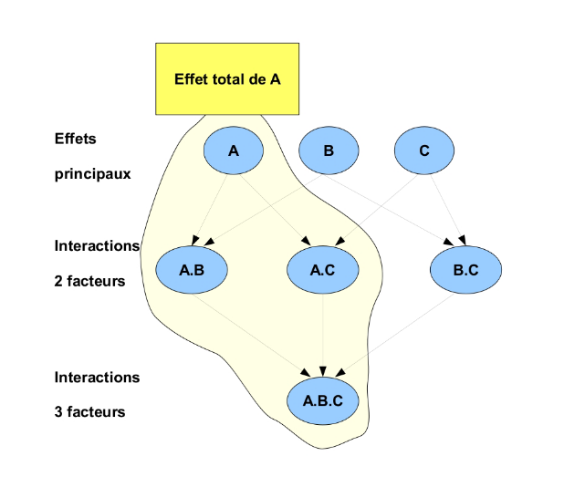

Termes factoriels composant l’indice de sensibilité total de l’entrée A

Pour le dire d’une troisième façon, la sensibilité totale mesure donc la variance moyenne (normalisée) de Y quand toutes les entrées sauf $X_i$ sont fixées. Lorsque l’on souhaite effectuer un factor fixing, c’est-à-dire choisir les entrées à fixer, on utilise principalement les indices totaux. Les indices de sensibilité totaux très faibles correspondent en effet aux entrées que l’on peut fixer arbitrairement sans modifier sensiblement le comportement du modèle.

#### 3.1.4.3 algorithme

Pour retirer une variable j du processus de prédiction de l’arbre on procède comme suit. La partition de l’espace de covariables obtenue avec les feuilles terminales de l’arbre d’origine est projetée selon la j-ième direction et les sorties des cellules de cette nouvelle partition projetée sont recalculées avec les données d’entraînement. Ce procédé permet de retirer la variable j du processus de prédiction de l’arbre. Ensuite, il est possible de calculer la précision de l’estimation de la forêt projetée grâce aux échantillons OOB, de soustraire cette précision de la précision initiale et de normaliser la différence obtenue par $V [Y ]$ pour obtenir le Sobol-MDA pour $X_j$.

En pratique, les données d’entraînement et les échantillons OOB de l’arbre sont mis dans l’arbre et envoyés à droite et à gauche du noeud si celui-ci fait une division sur la covariable j. A la fin, chaque donnée peut donc se retrouver dans plusieurs feuille terminales. Pour chaque donnée OOB, la prédiction associée est donc la moyenne des sorties des données d’entraînement qui sont tombées sur les mêmes feuilles terminales que la donnée OOB. En d’autres termes on calcule l’intersection entre les feuilles terminales où est tombée la donnée OOB et les feuilles terminales où sont tombées les données d’entraînement. Cette intersection donne la cellule projetée. Ce mécanisme est équivalent à projeter la partition de l’arbre sur le sous-espace engendré par $X^{(-j)}$.

Ecrivons cela plus formellement.

On note $\Theta$ le vecteur qui contient les indices des vecteurs de l’échantillon initial utilisé pour l’entraînement de l’arbre auquel il est associé et on note $m_n(x,\Theta)$ l’estimation de la valeur de la sortie de x par un arbre entraîner avec un échantillon indiqué par $\Theta$ , Sobol-MDA prédit donc $m^{(-j)}(X^{(-j)})=E[m(X)|X^{(-j)}]$.

On note $A_n(X,\Theta)$ la cellule de la partition de l’arbre d’origine où X tombe et on note $A_n^{(-j)}(X^{(-j)},\Theta)$ la cellule associé de la partition projetée. On note l’estimation par l’arbre projeté associé $m_n^{(-j)}(X^{(-j)},\Theta)$ et l’estimation par la forêt projeté associée $m_{M,n}^{(-j,OOB)}(X_i^{(-j)},\Theta_{(M)})$. Ces estimations sont définies de la manière suivante :

$$m_n^{(-j)}(X^{(-j)},\Theta)=\frac{\sum_{i=1}^{a_n}
Y_i 1_{X_i \in A_n^{(-j)}(X^{(-j)},\Theta)}}{\sum_{i=1}^{a_n} 1_{X_i \in
A_n^{(-j)}(X^{(-j)},\Theta)}}$$
$$m_{M,n}^{(-j,OOB)}(X_i^{(-j)},\Theta_{(M)})=\frac{1}{|\Lambda_{n,i}|}
\sum_{l \in \Lambda_{n,i}} m^{(-j)}_{n}(X^{(-j)}_i,
\Theta_l)1_{|\Lambda_{n,i}|>0}$$

L’indice de Sobol-MDA est donné par la différence normalisée de l’erreur carrée (calculée grâce aux OOB) de la forêt projetée et l’erreur carrée (calculée grâce aux OOB) de la forêt initial, Sobol-MDA est donc défini de la manière suivante :

$$\widehat{S-MDA}_{M,n}(X^{(j)})=\frac{1}{\hat{\sigma}^2_Y}\frac{1}{n}\sum^{n}_{i=1}\{Y_i-m_{M,n}^{(-j,OOB)}(X_i^{(-j)},\Theta_{(M)})\}^2$$
$$-\{Y_i-m_{M,n}^{(OOB)}(X_i,\Theta_{(M)})\}^2$$
où $\hat{\sigma}^2_Y=\frac{1}{n-1}\sum^{n}_{i=1}(Y_i-\bar{Y})^2$ est la variance standard estimée de la réponse Y.

#### 3.1.4.4 convergence

Dans l’article Bénard, Da Veiga, and Scornet (2022), , sous certaines hypothèses sur la construction du random-forest faciles à mettre en place, la convergence des indices Sobol-MDA vers les indices de Sobol totaux lorsque le nombre d’échantillons augmente a été prouvé. Nous présentons ici l’idée générale de la preuve.

L’indice de Sobol total $S_j^T=\frac{E[Var(G(X)|X^{(-j)})]}{VarG(X)}$, s’écrit, dans le cas du random forest, en remplaçant G(X) par l’estimation obtenue par la forêt, l’indice de Sobol total s’écrit donc $S_j^T=\frac{E[Var(m(X)|X^{(-j)})]}{Var[m(X)]}=\frac{E[(m(X)-E[m(X)|X^{(-j)}])^2]}{Var(m(X))}$. On cherche donc à montrer que
$$\widehat{S-MDA}_{M,n}(X^{j})\overset{p}{\longrightarrow}S_j^T$$

Pour cela, on majore $E[\widehat{S-MDA}_{M,n}(X^{j})\sigma_Y^2-E[(m(X)-E[m(X)|X^{(-j)}])^2]]$ par une expression dépendant de n en faisant une décomposition sur laquelle on applique l’inégalité triangulaire. On obtient alors
$$\widehat{S-MDA}_{M,n}(X^{j})\sigma_Y^2\overset{p}{\longrightarrow}E[(m(X)-E[m(X)|X^{(-j)}])^2]$$

Ensuite l’indice de Sobol-MDA est normalisé par la variance standard estimée $\sigma_Y^2$ de la sortie Y qui est convergente par la loi des grands nombres. Grâce au “mapping theorem” on a
$$\frac{1}{\hat\sigma_Y^2}\overset{p}{\longrightarrow}\frac{1}{V[Y]}$$
Sobol-MDA est donc le produit de deux quantités aléatoires qui converge en probabilité donc on obtient bien
$$\widehat{S-MDA}_{M,n}(X^{j})\overset{p}{\longrightarrow}\frac{E[(m(X)-E[m(X)|X^{(-j)}])^2]}{V[Y]}=S_j^T$$

#### 3.1.4.5 avantages

L’approche de Williamson et al. (2023), consitant à réentraîner une forêt sans l’une des covariables, permet elle aussi d’approximer les indices de Sobol totaux. Néanmoins, l’avantage de l’approche Sobol-MDA est qu’elle nécessite seulement de faire des prédiction supplémentaires avec la forêt, ce qui est plus rapide que le réentraînement d’une forêt. L’algorithme de Williamson et al. (2023) a une complexité en $O\{Mp^2nlog^2(n)\}$ qui est quadratique avec les dimensions et l’algorithme Sobol-MDA a une complexité en $O\{Mnlog^3(n)\}$ ce qui est un grand avantage lorsque l’on travaille avec un grand nombre de varaibles d’entrée.

Concernant l’analyse des résultats, nous avons tout d’abord exploré les sorties du modèles pour comprendre leur dynamique. Nous avons étudié la dynamique temporelle des sorties, la propagation de l’incertitude d’entrée sur les sorties ainsi que la variabilité des sorties lorsqu’un seul des paramètres varie et que les autres sont fixés. Nous avons ensuite pu construit 2 métamodèles random forests en utilisant ranger (Wright and Ziegler (2015)), l’un lorsque les paramètres sont dépendants et l’autre losrque les paramètres sont indépendants. Nous avons ensuite estimé les indices de Sobol totaux sur les randoms forests en utilisant la méthode “Sobol-MDA”. D’une part nous avons pu voir les paramètres qui inluent le plus sur les sorties et d’autre part nous avons pu comparer les valeurs des indices pour les paramètres dépendants et indépendants ainsi que les valeurs des indices obtenues selon les différentes méthodes de calcul (Sobol-MDA ou méthode classique du package sensitivity). Finalement, pour comprendre comment l’intensité de la dépendance influe sur l’analyse de sensibilité, nous avons construit des random forests avec des jeux de données dont les paramètres étaient de plus en plus corrélés. Nous avons calculé les indices de Sobol-MDA sur ces random forest et tracer l’évolution des valeurs des indices en fonction de la corrélation entre les paramètres d’entrée.

## 3.2 Démarche mise en oeuvre

Pour réaliser cette étude, nous construisons plusieurs fichiers csv contenant les combinaisons des valeurs des paramètres d’entrée, et plus précisément un fichier avec des paramètres d’entrée suivant une distribution avec une hypothèse d’indépendance, d’autres avec différentes hypothèses de dépendance, et d’autres avec un paramètre fixe et 4 qui varient. Pour chaque fichier nous avons faits des simulations avec ISIS pour chacunes des combinaisons de paramètres d’entrée. Nous avons ensuite construits plusieurs fichiers rds contenant les valeurs des paramètres associés aux valeurs des sorties du modèle ISIS.

Concernant l’analyse des résultats, nous avons tout d’abord exploré les sorties du modèles pour comprendre leur dynamique. Nous avons étudié la dynamique temporelle des sorties, la propagation de l’incertitude d’entrée sur les sorties ainsi que la variabilité des sorties lorsqu’un seul des paramètres varie et que les autres sont fixés. Pour chaque export du modèle (biomasse, biomasse de géniteurs et captures de pêche), nous avons ensuite construit 2 métamodèles random forests en utilisant ranger (Wright and Ziegler (2015)), l’un lorsque les paramètres sont dépendants et l’autre lorsque les paramètres sont indépendants. Nous avons ensuite estimé les indices de Sobol totaux sur les randoms forests en utilisant la méthode “Sobol-MDA”. D’une part nous avons pu voir les paramètres qui inluent le plus sur les sorties et d’autre part nous avons pu comparer les valeurs des indices pour les paramètres dépendants et indépendants ainsi que les valeurs des indices obtenues selon les différentes méthodes de calcul (Sobol-MDA ou méthode classique shapleysobol_knn() du package sensitivity). Finalement, pour comprendre comment l’intensité de la dépendance influe sur l’analyse de sensibilité, nous avons construit des random forests avec des jeux de données dont les paramètres étaient de plus en plus corrélés. Nous avons calculé les indices de Sobol-MDA sur ces random forest et tracer l’évolution des valeurs des indices en fonction de la corrélation entre les paramètres d’entrée.

# 4 Données

L’un des objectifs de cette étude étant d’évaluer la sensibité des sorties du modèle ISIS-Fish à certains paramètres d’entrée, nous allons dans ce chapitre présenter plus en détails le simulateur ISIS-Fish (voire Mahévas and Pelletier (2004)). Ensuite nous nous intéressons à la pêcherie langoustinière et aux paramètres d’entrée que nous allons faire varier pour évaluer la sensibilité. Finalement nous expliquerons le plan de simulations mis en place.

## 4.1 Présentation d’ISIS-Fish

ISIS-Fish (Integration of Spatial Information and Simulation for Fisheries) est un simulateur des dynamiques de pêche. Il peut aider les pêcheurs, les managers, les entreprises et les scientifiques dans leur recherche de la meilleure gestion écosystémique spatialisée des pêches. Mais comment marche ce modèle mécanistique ? Tout d’abord, il faut avoir en tête que ce modèle est composé de trois sous-modèles qui intéragissent à travers le temps et l’espace. Précisons que le pas de temps est le mois et qu’un maillage de l’espace est réalisé pour obtenir des zones. Parmi les sous-modèles on trouve la modélisation du management, de l’activité de pêche et des dynamiques des populations de poissons. Leurs intéarctions sont représentées dans la Figure 3.

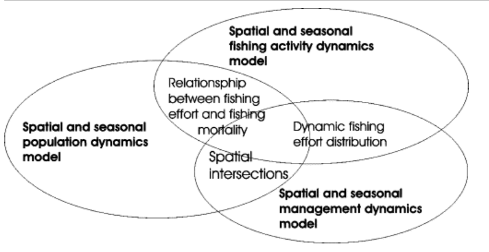

Une vue générale du modèle de pêcherie spatiale mixte décomposé en trois sous-modèles interagissant à travers le temps et l’espace. Les sous-modèles interagissent via une intersection spatiale et temporelle. (trouvé dans Mahévas and Pelletier (2004))

La composante “management” simule les règles qui s’appliquent sur la pêche (mesures de sélectivité, TCA, zones protégées, saisons interdites, etc). La composante “populations de poissons” simule le cycle de vie des poissons. Chaque mois les poissons grandissent, migrent, se reproduisent, et certains meurent de causes naturelles (voire Figure 4). Pour chaque mois, une carte de l’abondance des poissons par zone est produite par ISIS.

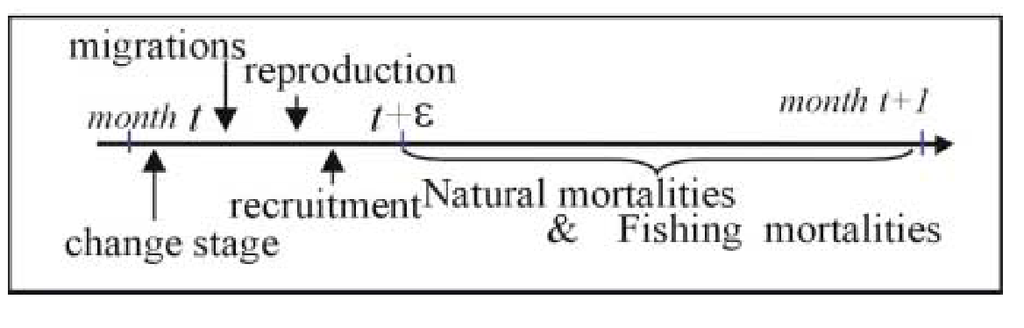

Chronologie des processus considérés dans le modèle de population, fishing mortalities provient de l’intéraction entre la composante “dynamique des populations” et “dynamique des pêches”

La composante “dynamique des pêches” simule l’exploitation des ressources halieutiques. Celle-ci est quantifiée par l’effort de pêche, qui dépend des engins de pêche utilisés et de la durée passée à pêcher. Les navires de pêche ne sont pas représentés individuellement mais ils sont organisés en flottes rattachées à des zones de pêche selon la durée passée en mer et selon leurs caractéristiaues techniques. Pour chaque flotte, des stratégies décrivent la distribution de l’effort de pêche en fonction des métiers et des mois. Les statégies peuvent changer en fonction des mesures de management, de l’abondance des populations, du prix de l’essence et du prix de vente des poissons. Chaque mois, la carte (toujours à l’échelle des zones) de l’effort de pêche est alors mise à jour.

A la fin de chaque mois, ISIS-Fish superpose la carte de l’effort de pêche sur celle de l’abondance des populations. Pour les espèces que l’on considère “immobiles”, les captures par la flotte sont alors calculées sur les zones d’intersection (car on a donc sur ces zones des poissons et des pêcheurs). Pour les espèces qui se déplacent, les captures ne sont pas seulement calculées sur le nombre d’animaux marins présents dans la zone d’intersection mais aussi sur ceux des zones adjacentes qui passeront probablement par les zones d’intersection durant la durée de la pêche. En fonction des stratégies mises en place et de la réglementation, les pêcheurs décident des poissons à garder et de ceux à remettre à l’eau, on représente cela dans le modèle avec la probabilité de survie après relâchement.

Avant d’utiliser ISIS-Fish comme un outil d’aide à la prise de décision, les valeurs des paramètres doivent être sélectionnées pour représenter au mieux la pêcherie étudiée. Pour cela, des données de pêche et des données d’études sont utilisées et des hypothèses sont faites dans le cas d’informations manquantes. Pour valider ou invalider les paramètres, on compare les résultats du simulateur avec les données sur la situation passée de la pêcherie étudiée.

Après validation des paramètres on peut simuler différents scénarios de management pour voir lequel conviendrait le mieux. Par exemple, on peut estimer le poids des captures de pêche dans 5 ans dans le cadre de mise en place d’une zone de pêche protégée. Des simulations sont alors faites avec des valeurs de paramètres prises aléatoirement dans leur intervalle de confiance. On obtient alors non pas une valeur de sortie mais un intervalle de valeurs de sortie. On prend ainsi en compte la propagation de l’incertitude d’entrée dans la sortie. Un des objectif est de réduire les incertitudes en entrée pour ainsi réduire l’incertitude en sortie. L’analyse d’incertitude est très utiles dans le sens où, en nous fournissant les paramètres d’entrée qui augmente le plus la variance de la sortie, elle nous permet de connaître les paramètres pour lesquels on doit chercher en prorité à réduire l’incertitude.

## 4.2 Précisions sur la pêcherie langoustinère

La pêcherie langoustinière étudiée ici est inspirée de la pêcherie de la grande vasière dans le golfe de Gascogne paramétrée avec ISIS-Fish. La paramétrisation a été simplifiée pour faciliter l’utilisation et la compréhension de ce modèle.

Le cycle de vie de la langoustine est décrit dans le modèle au travers de 10 classes d’âge qui se distribuent spatialement sur 9 rectangles de taille 1 degré en longitude et 0.5 degré en latitude. Chaque classe d’âge se caractérise par une largeur moyenne de la carapace de la tête (longueur céphalothoracique) qui permet de décrire l’interdiction de débarquer des langoustines dont la carapace de la tête est plus petite que 20 mm (réglementation de la taille minimale de débarquement). Si une langoustine trop petite est capturée, elle est rejetée dans la mer avec une chance de survie (proportion de survie). Le renouvellement annuel des langous- tines juvéniles est dépendant de la quantité de langoustines en âge de se reproduire (relation stock-recrute- ment de Beverton et Holt). Dans cette description, on fait l’hypothèse qu’il n’y a pas de dispersion des larves à l’extérieur des 9 rectangles ni entre les rectangles. A chaque mois de l’année, le modèle décrit la carte du nombre de langoustines par classe d’âge (abondance ou biomasse en poids). Les langoustines sont capturées par plusieurs groupes de bateaux de pêche (chalutiers) qui diffèrent par leur port d’attache, leur longueur, les espèces ciblées (métiers : langoustiniers, poissons benthiques, poissons démersaux) et leurs pratiques annuelles des métiers (stratégies). Le temps passé à pêcher (effort de pêche) est spatialisé et se distribue différemment selon les métiers et les saisons dans les 9 rectangles. Selon le métier, cet effort de pêche est plus ou moins efficace pour capturer des langoustines et l’efficacité de pêche change au cours du temps (dérive d’efficacité de pêche). A chaque mois de l’année, en multipliant l’effort de pêche par un facteur appelé capturabilité, le modèle calcule une carte de la mortalité par pêche des langoustines pour chaque métier. Chaque mois, sur la période de 5 ans simulée, le modèle prédit les captures, la biomasse et la biomasse féconde de langoustine par rectangle en superposant les cartes de mortalité par pêche des métiers et la carte d’abondance des langoustines. Pour simplifier les exports des résultats du modèles, on a choisi de sommer les résultats sur les zones et sur les mois. On obtient ainsi la biomasse, la biomasse féconde et les captures de pêche (en tonnes) sur la zone de présence totale des langoustines au début du mois de janvier pour les 5 années suivantes.

## 4.3 Paramètres en entrée

### 4.3.1 Choix des paramètres incertains

Dans cette étude, nous nous sommes concentrées sur 5 paramètres incertains :

- la proportion de survie : pourcentage de survie des captures non débarquées pour des raisons diverses (taille illégale, poisson endommagé, absence de marché ou dépassement des quotas).
- la dérive d’efficacité de pêche : coefficient d’évolution annuelle de l’efficacité de pêche.
- le facteur de standardisation des engins : coefficient de standardisation d’une heure de pêche entre différents engins.
- la mortalité naturelle : taux de mortalité naturelle des langoustines selon la classe d’âge
- la fécondité : taux de fécondité (nombre d’oeufs ou de juvéniles) des langoustines selon la classe d’âge

Chacun de ces paramètres a une valeur de référence et un intervalle d’incertitude autour de cette valeur de reference (voir figure 5). Dans cette étude on fait l’hypothèse que toutes les valeurs possibles de cet intervalle ont la même probabilité de se réaliser (distribution uniforme).

[figure not shown]

Tableau de la valeur de référence ainsi que l’intervalle d’incertitude des paramètres

### 4.3.2 Distributions des valeurs d’entrée

On peut concevoir que plus le taux de mortalité naturelle des langoustines est élevé, plus les langoustines sont fragiles et plus elles ont de chances de mourrir après avoir été relâchées par les pêcheurs. C’est pourquoi nous avons simulé une hypothèse de dépendance (corrélation négative) entre les paramètre “Mortalité et survie”. De plus, on peut supposer que plus la dérive d’efficacité de pêche est importante, plus les quantités de langoustines pêchées augmente, plus les pêcheurs mettent de temps à trier celles à relâcher et plus elles sont serrées dans les filets et ainsi plus la proportion de survie après relâchement diminue. C’est pourquoi nous avons simulé une hypothèse de dépendance (corrélation négative) entre les paramètre “Dérive et Survie”. Voici la distribution des valeurs de nos paramètres d’entrée dans le cas où on a supposé une dépendance.

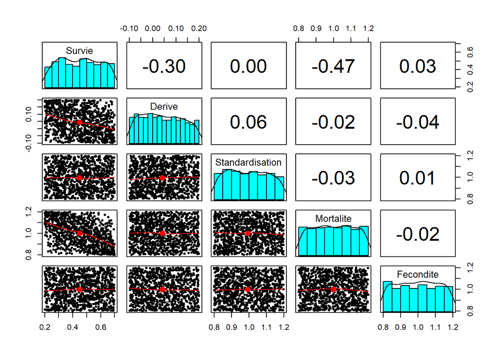

## 4.4 Plan de simulation

En vue d’étudier la variabilité des sorties lorsqu’un seul des paramètres varie et que les autres sont fixés nous faisons 50 simulations en faisant varier un seul paramètre. Nous répétons l’opération pour chaque paramètre. Pour obtenir les données d’entraînement du random forest et estimer les indices de Sobol- MDA, nous faisons 1000 simulations avec des valeurs de paramètres tirées aléatoirement dans leur intervalle respectif, avec ou sans hypothèse de dépendance suivant le cas. Voici un exemple de fichier de données utilisé pour la construction des random forests et l’analyse. Ce fichier contient les combinaisons des paramètres d’entrée, les résultats associés et ce pour chaque année (voir figure 6).

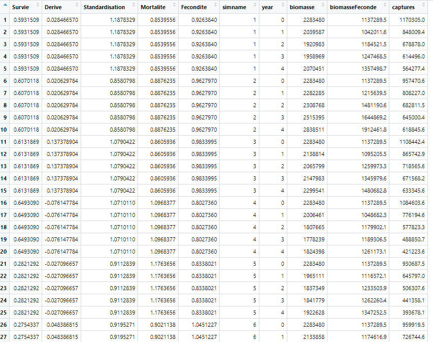

Exemple d’un fichier de données utilisé dans notre étude”

# 5 Résutats

## 5.1 Exploration des sorties ISIS

Dans cette partie, nous étudions la dynamique temporelle des sorties d’ISIS, la variabilité des sorties lorsqu’un seul des paramètres varie et que les autres sont fixés ainsi que la propagation de l’incertitude d’entrée sur les sorties (par année ainsi que sa série temporelle).

### 5.1.1 Quelle est la dynamique temporelle des sorties lorsque les entrées sont mises à leur valeur de référence ?

#### 5.1.1.1 Biomasse

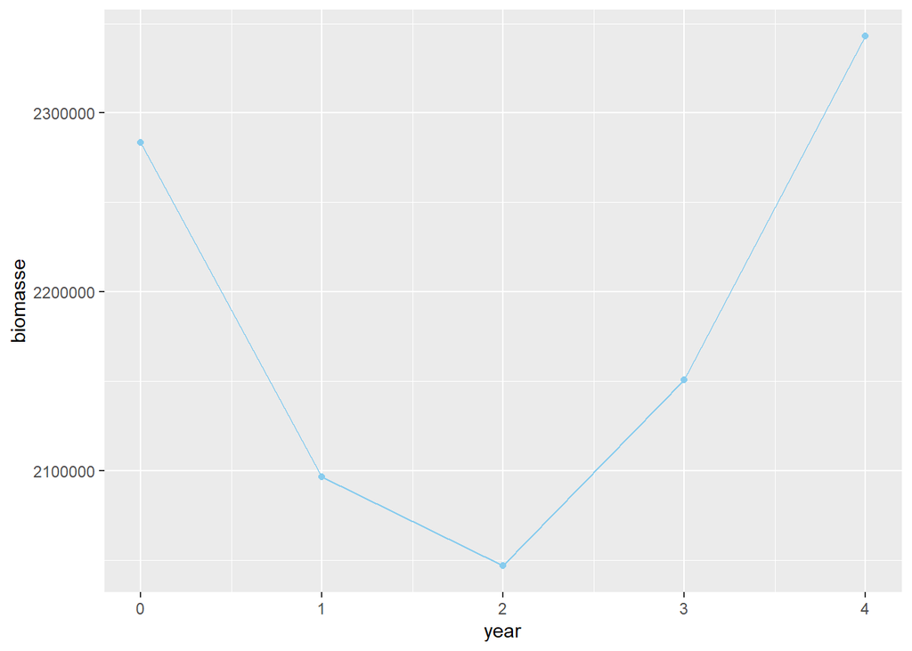

#### 5.1.1.2 Biomasse féconde

On remarque que la biomasse féconde n’a pas la même diminution que la biomasse entre l’année 0 et l’année 2. On peut supposer que des langoustines sont passées de non fécondes à fécondes entre ces années ce qui a compensé les pertes.

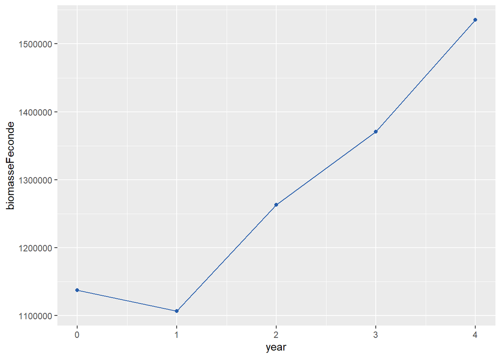

#### 5.1.1.3 Poids des captures de pêche

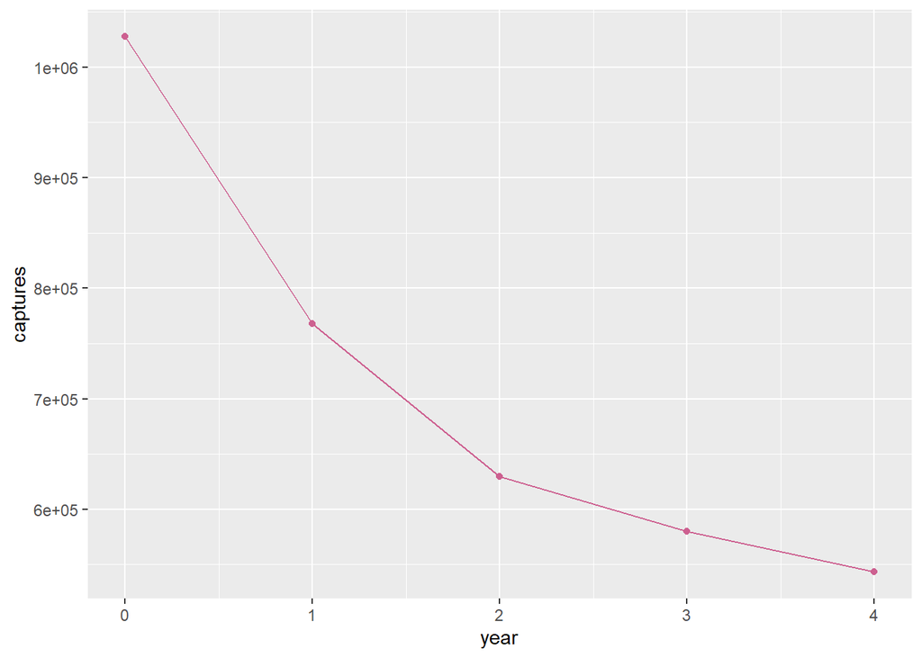

### 5.1.2 De quelle manière varient les sorties lorsqu’un seul des paramètres varie et que les autres sont fixés à leur valeur de référence ?

#### 5.1.2.1 Survie

Etudions les variations des sorties lorsque l’on fait varier la proportion de survie après relâchement.

##### 5.1.2.1.1 Biomasse

La biomasse augmente lorsque la proportion de survie après relâchement augmente, le contraire nous aurait alerté.

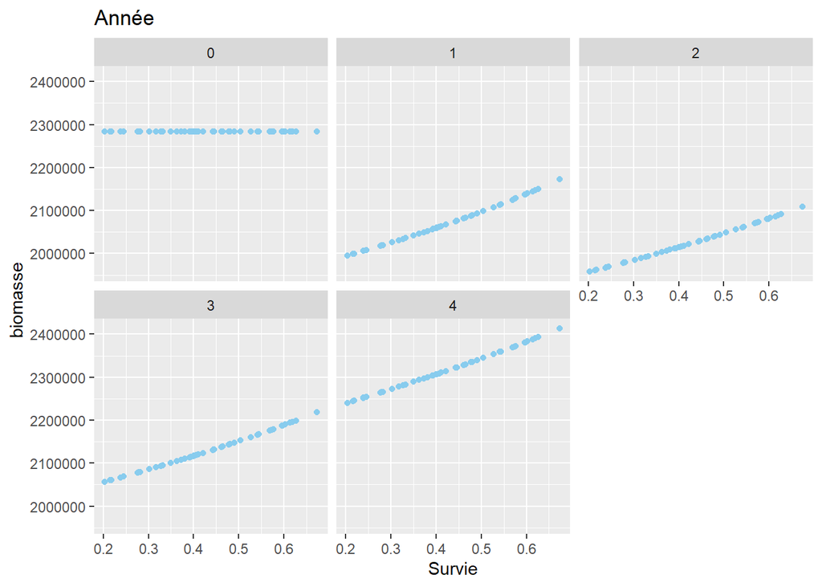

##### 5.1.2.1.2 Biomasse Feconde

La biomasse féconde augmente lorsque la proportion de survie après relâchement augmente, mais seulement à partir de la deuxième année. Ceci s’explique car les langoustines relâchées sont celles inférieures à une certaine taille et par conséquent celles non fécondes. Il faut attendre un an ou plus pour qu’elle passe à l’âge fécond.

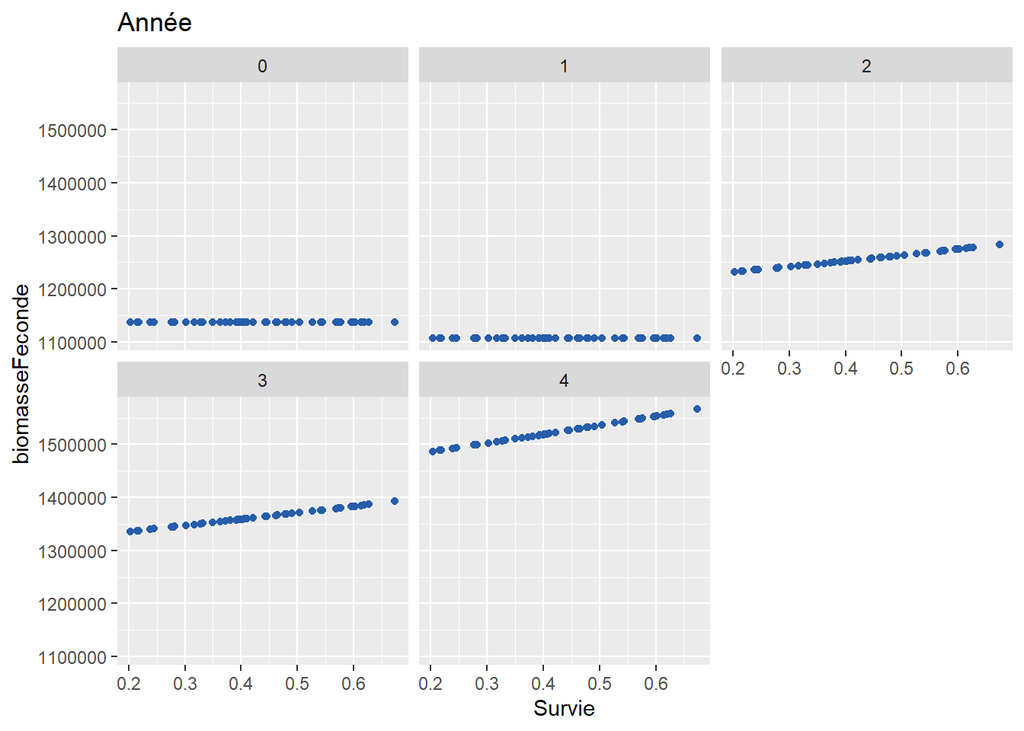

##### 5.1.2.1.3 Poids des captures

Le poids des captures de pêche augmente lui aussi lorsque la proportion de survie après relâchement augmente.

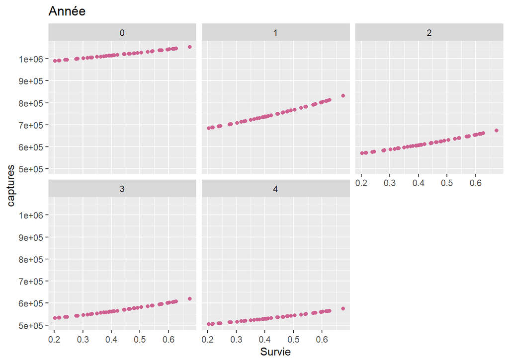

#### 5.1.2.2 Derive

Etudions les variations des sorties lorsque l’on fait varier la dérive d’efficacité de pêche.

##### 5.1.2.2.1 Biomasse

La diminution de la biomasse suivant l’augmentation de la dérive s’intensifie au cours des années. Ceci s’explique car si la dérive augmente cela signifie que les pêcheurs s’améliorent d’années en années.

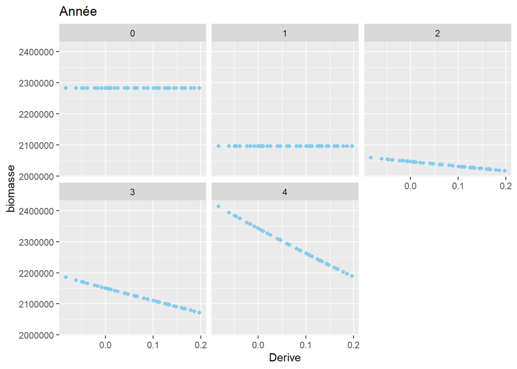

##### 5.1.2.2.2 Biomasse Feconde

La diminution de la biomasse féconde suivant l’augmentation de la dérive s’intensifie au cours des années. Ceci s’explique car si la dérive augmente cela signifie que les pêcheurs s’améliorent d’années en années.

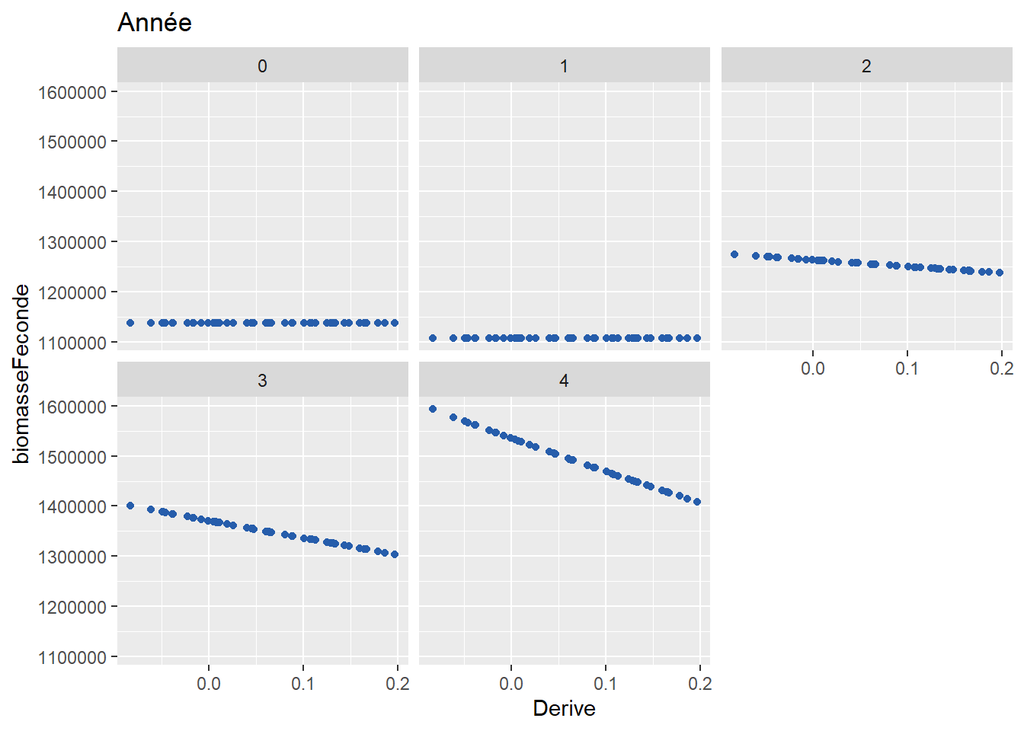

##### 5.1.2.2.3 Poids des captures

L’augmentation des captures de pêche suivant l’augmentation de la dérive s’intensifie au cours des années. Ceci s’explique car si la dérive augmente cela signifie que les pêcheurs s’améliorent d’années en années.

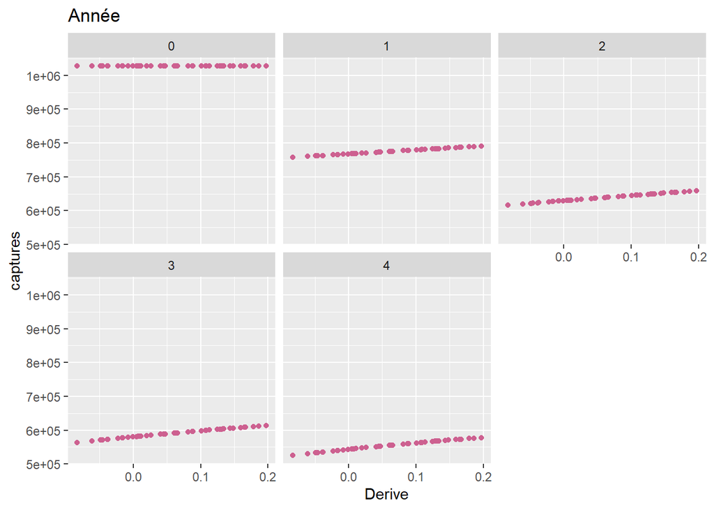

#### 5.1.2.3 Standardisation

Etudions les variations des sorties lorsque l’on fait varier le facteur de standardisation des engins.

##### 5.1.2.3.1 Biomasse

La biomasse diminue lorsque la standardisation augmente.

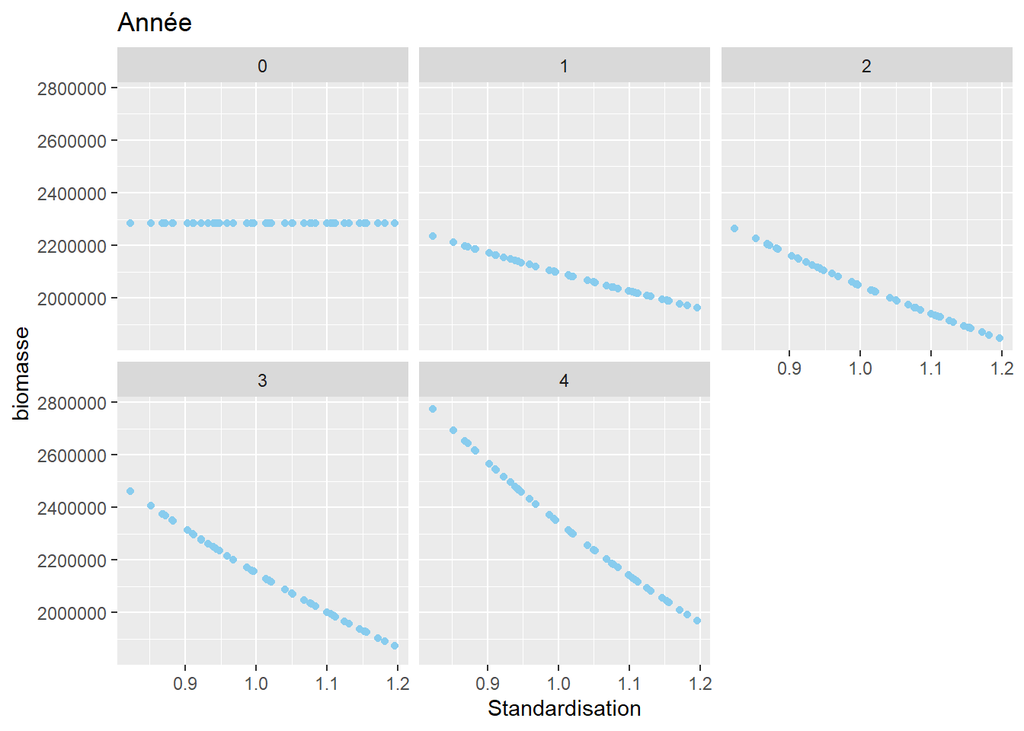

##### 5.1.2.3.2 Biomasse Feconde

La biomasse féconde diminue lorsque la standardisation augmente.

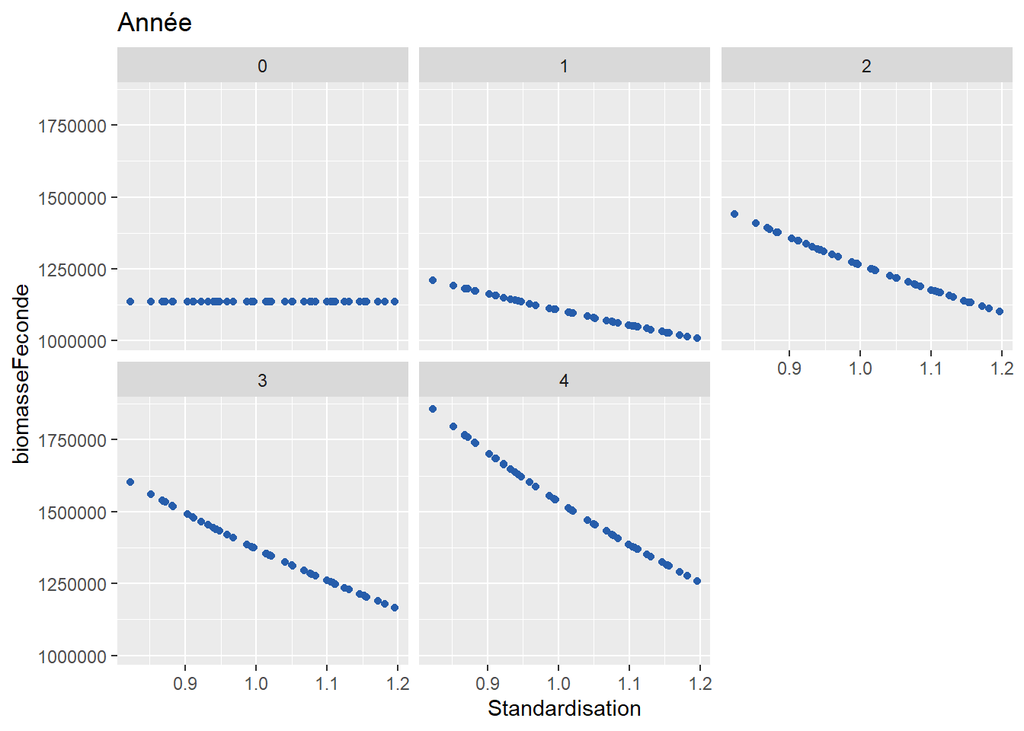

##### 5.1.2.3.3 Poids des captures

L’année 0, les captures de pêche augmentent lorsque la standardisation augmente. Les années suivantes, elles stagnent voir diminuent, ce qui peut s’expliquer par le fait que les pêcheurs en ont trop pêcher l’année 0 et qu’il faut du temps pour que le stock se refasse.

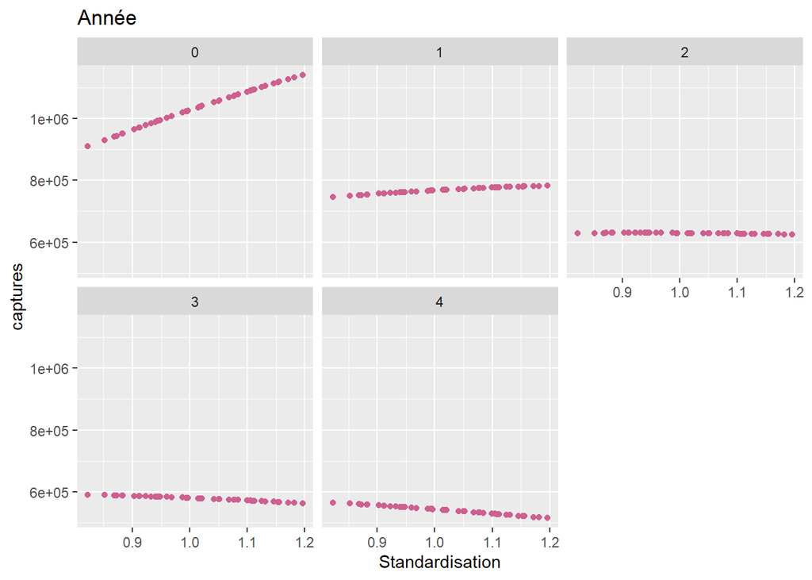

#### 5.1.2.4 Mortalite

Etudions les variations des sorties lorsque l’on fait varier la mortalité naturelle.

##### 5.1.2.4.1 Biomasse

La biomasse diminue lorsque la mortalité naturelle augmente, le contraire nous aurait alerté.

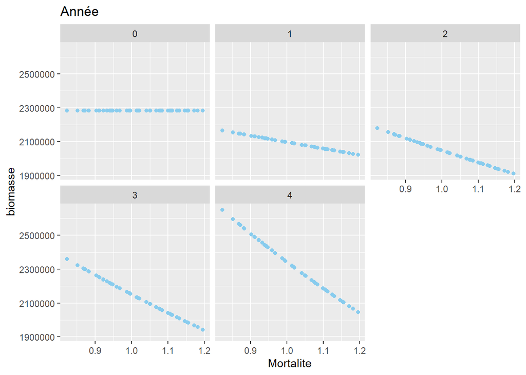

##### 5.1.2.4.2 Biomasse Feconde

La biomasse de géniteurs diminue lorsque la mortalité naturelle augmente, le contraire nous aurait alerté.

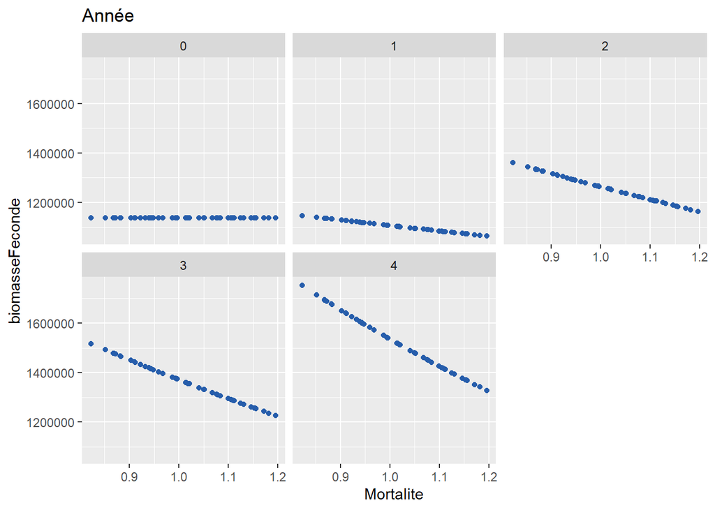

##### 5.1.2.4.3 Poids des captures

Le poids des captures diminue lorsque la mortalité naturelle augmente, le contraire nous aurait alerté.

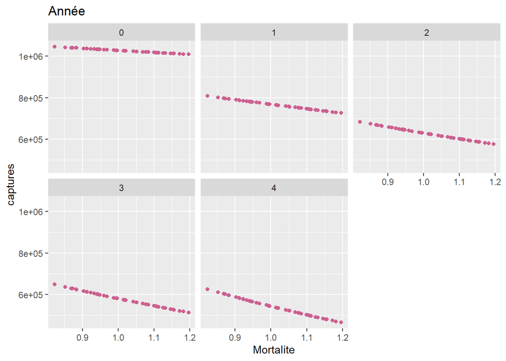

#### 5.1.2.5 Fecondite

Etudions les variations des sorties lorsque l’on fait varier la fécondité.

##### 5.1.2.5.1 Biomasse

Lorsque la fécondité augmente, l’augmentation de la biomasse s’intensifie au cours des années. En effet, comme le modèle prédit la biomasse en unité de masse, les nouveaux nés qui ont un poids faible ne font pas beaucoup augmenté le poids de la biomasse la 1ère année mais plus ils grandissent plus ils font augmenté le poids de la biomasse totale.

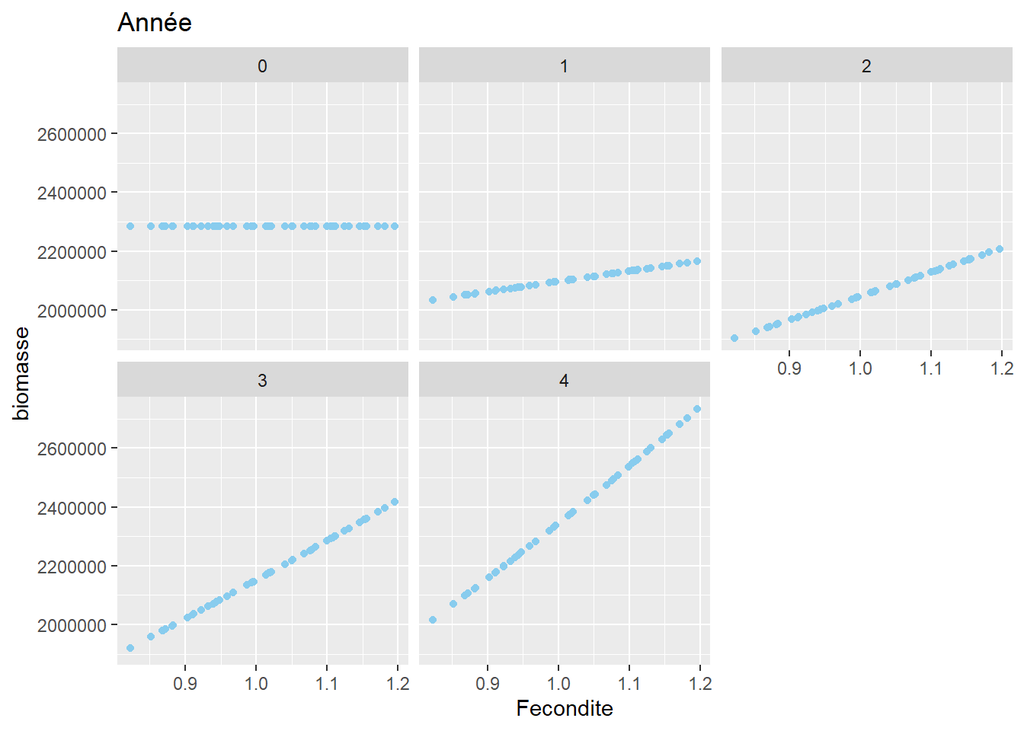

##### 5.1.2.5.2 Biomasse Feconde

L’augmentation du taux de fécondité ne fait augmenté la biomasse féconde qu’à partir de la troisième année car c’est le temps qu’il faut au nouveaux-nés pour passés de non féconds à féconds.

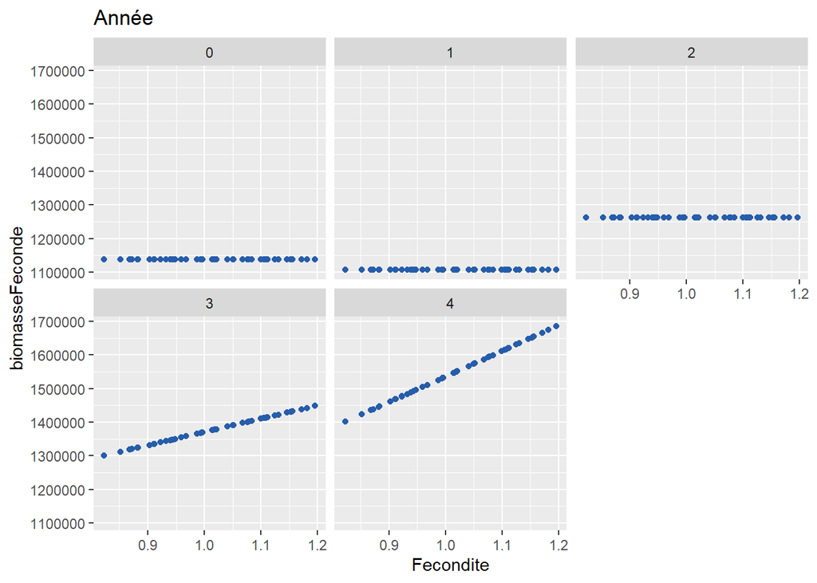

##### 5.1.2.5.3 Poids des captures

Lorsque la fécondité augmente, l’augmentation du poids des captures s’intensifie au cours des années car les nouveaux nés grossissent progressiment.

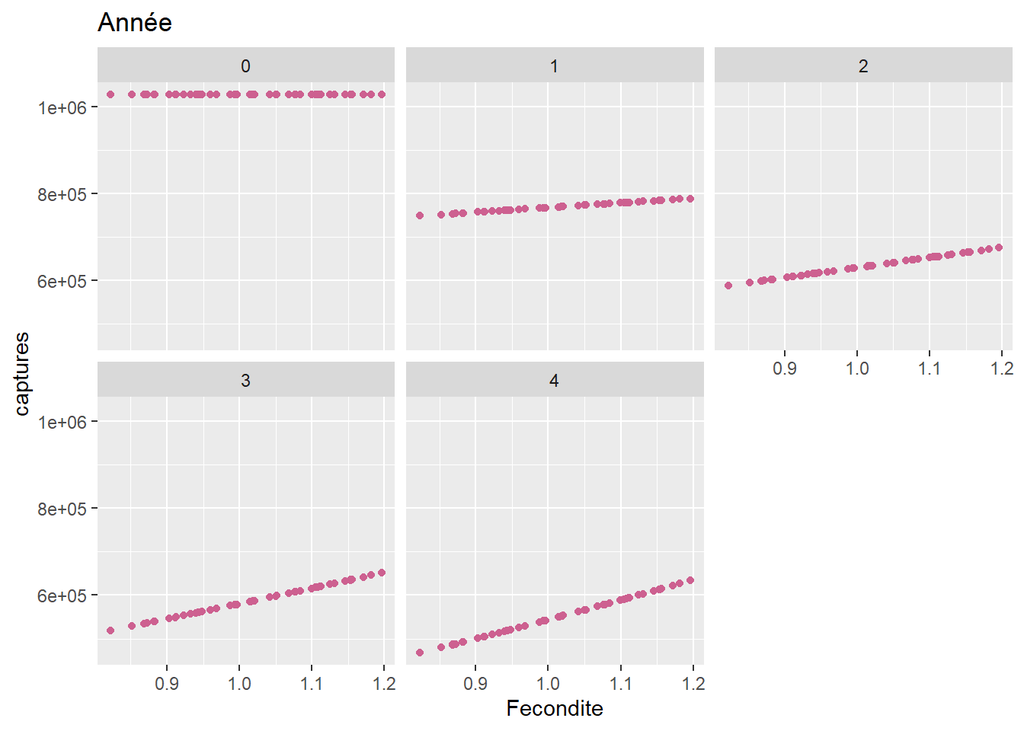

### 5.1.3 Quelle est la dynamique temporelle des sorties et son incertitude lorsque les paramètres d’entrée varient conjointement sur leur intervalle de confiance respectif et avec une hypothèse de dépendance ?

#### 5.1.3.1 Biomasse

L’incertitude sur les sorties augmente avec les années. En effet, l’incertitude se propage à chaque pas de temps.

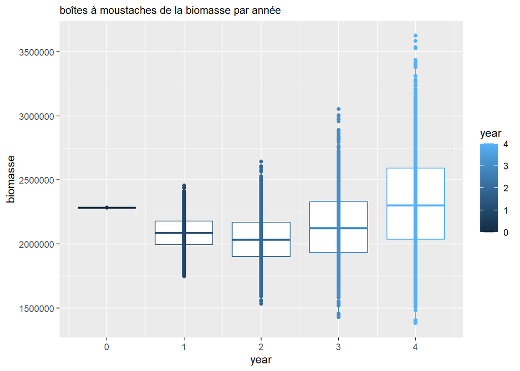

#### 5.1.3.2 Biomasse Feconde

L’incertitude sur les sorties augmente avec les années. En effet, l’incertitude se propage à chaque pas de temps.

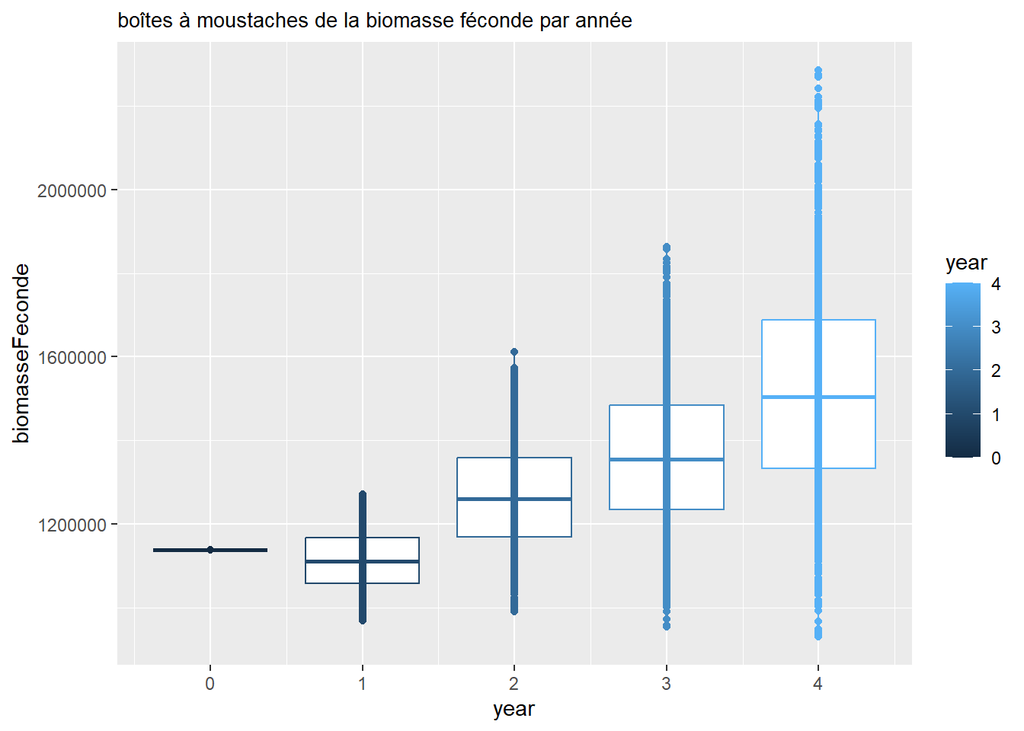

#### 5.1.3.3 Poids des captures de pêche

L’incertitude est très grande la première année, ce qui peut être dû à la distribution particulière des effectifs initiaux. Ensuite l’incertitude augmente avec le temps, comme dans les cas précédents.

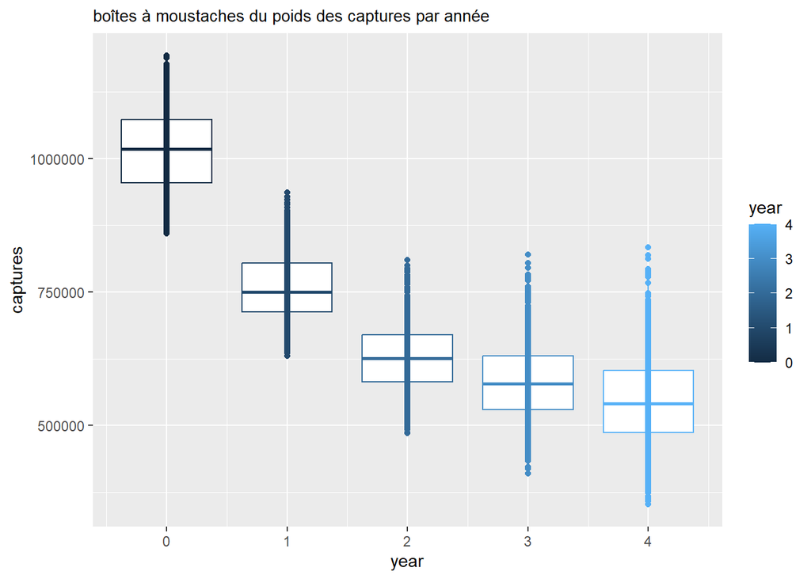

## 5.2 Analyse de sensibilité

### 5.2.1 Quelle est la dynamique temporelle des indices de Sobol-MDA lorsque les paramètres sont dépendants ?

#### 5.2.1.1 Biomasse

On remarque que pour l’année 1 la standardisation est le paramètre qui influe le plus sur la biomasse. Viennent ensuite mais loin derrière la survie, la fécondité et la mortalité. La dérive n’a que très peu d’importance sur la sortie. Cette ordre va ensuite changé la deuxième année car la fécondité va devenir plus importante dans le processus de prédiction tandis que la survie va devenir moins influente. On remarque que la fécondité devient de plus en plus influente au cours du temps, jusqu’à devenir 2ème dans le classement des paramètres par ordre d’influence juste derrière la standardisation. Sa faible influence dans les premières années s’explique par le fait que le poids des nouveaux nés ne fait pas beaucoup variés le poids de la biomasse totale en sortie. Ensuite, comme les nouveaux-nés grandissent la fécondité devient plus infleuente.

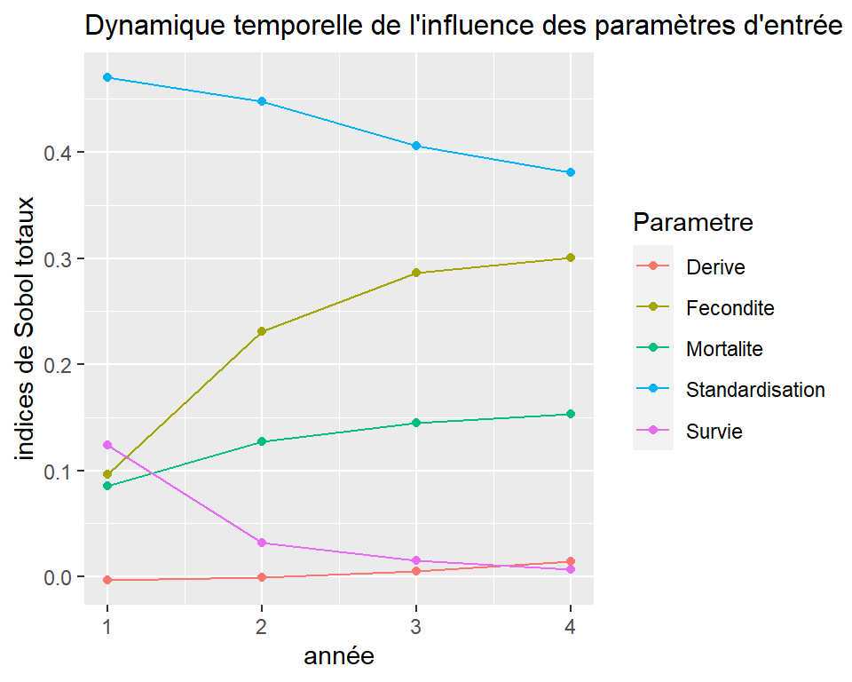

#### 5.2.1.2 Biomasse féconde

Pour cette sortie, la première année, seulement la standardisation et la mortalité ont une influence notable. Ensuite l’influence de la fécondité augmente lentement. En effet, il faut du temps pour que les variations de la fécondité se reflète sur la biomasse féconde car il faut le temps que les nouveaux nés deviennent des géniteurs pour être pris en compte dans cette sortie.

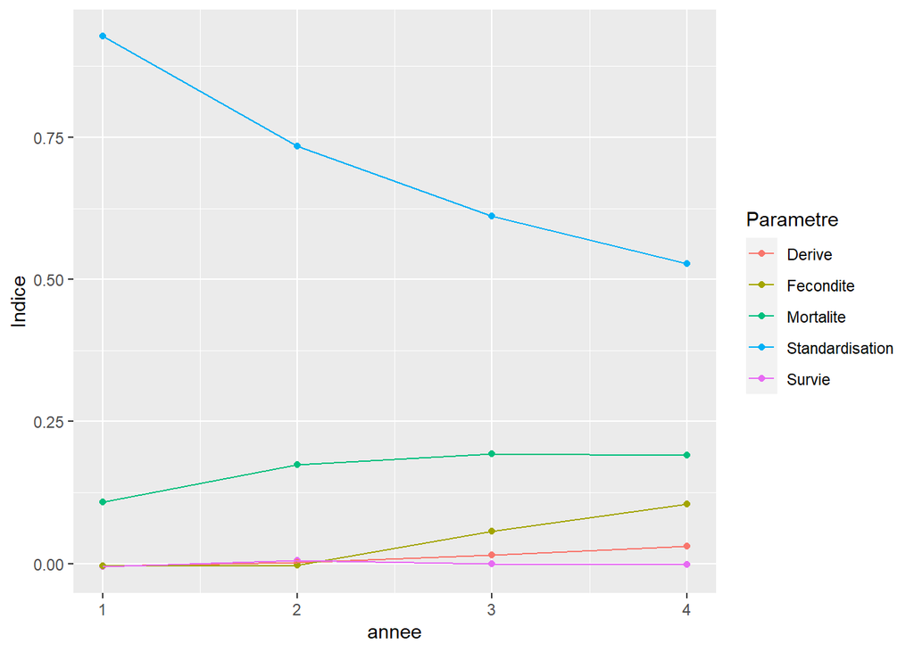

#### 5.2.1.3 Poids des captures de pêche

La première année, on remarque un classement tout à fait différent pour cette sortie. La survie est très influente et derrière elle on trouve la mortalité et la fécondité. Ensuite, comme dans le cas des autres sorties mais avec d’autres proportions, l’influence de la fécondité et de la mortalité augmente au cours du temps tandis que celle de la survie diminue fortement.

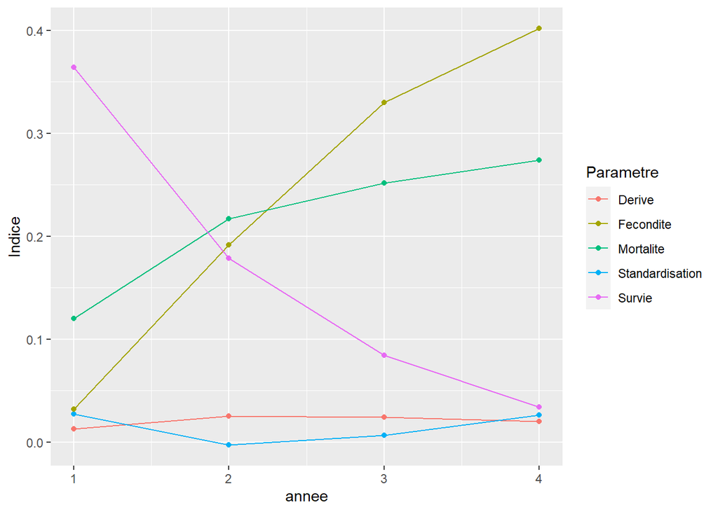